# 02_compara

zagor

2025-09-22

```r
rm(list = ls(all = TRUE))
gc()
```

```
##           used (Mb) gc trigger (Mb) max used (Mb)
## Ncells  625268 33.4    1434901 76.7   702048 37.5
## Vcells 1173293  9.0    8388608 64.0  1927980 14.8
```

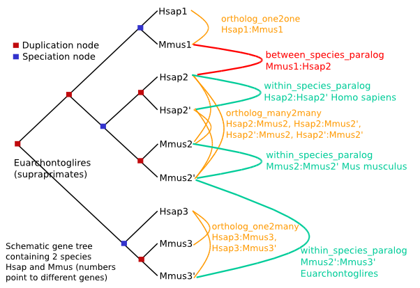

```r
library(magrittr)
library(ggplot2)
library(data.table)

`%nin%` = Negate(`%in%`)


setwd(dirname(rstudioapi::getActiveDocumentContext()$path))
```

https://www.ensembl.org/info/genome/compara/homology_types.html

https://www.ensembl.org/info/website/tutorials/compara.html

- Homologues are separated into Orthologues (across different species) and Paralogues (within a species).
- Whole genome alignments are determined as part of the Ensembl release cycle, incorporating new species and new assemblies.

https://www.ensembl.org/info/genome/compara/homology_method.html

https://www.ensembl.org/info/genome/compara/Ortholog_qc_manual.html

- The whole genome alignment score calculates the coverage of the alignment over the orthologue pair.
- In every orthology inference between two species, the set of orthologue pairs between the species is considered for high-confidence annotation. The GOC and WGA scores among others are used to determine which orthologies to tag as being high-confidence.
- The primary filter used to select the high-confidence set of orthologue pairs, consists of three thresholds for respectively the GOC score, the WGA coverage and the percentage identity of the orthologue pairs. The thresholds we use depend on the most recent common ancestor of the species pair, according to the table below. The primary filter is used if there are scores of either type (GOC or WGA) in the set of orthologues between the two species.
- The orthology between two genes will be classified as high confidence if the alignment between the two genes satisfies the percentage identity requirement and either GOC or WGA scores meet their thresholds.
- If GOC or WGA scores are not available or if no threshold is used for a set of orthologues, the pipeline will use fallback criteria, that is the prediction will be classified as high confidence if the percentage identity meets the threshold and the prediction is [tree compliant](https://www.ensembl.org/info/genome/compara/homology_types.html#betweenspeciesparalogues).

```r
clean_text = function(x) {
  if (is.character(x)) {
    # Remove all whitespace and quotes
    cleaned <- gsub("[\\s\"']", "", x, perl = TRUE)
    # Replace "NULL" with NA
    ifelse(cleaned == "NULL", NA, cleaned)
  } else {
    x
  }
}
```

# 1 plant selection

```r
fp = file.path('..', 'input', 'Compara')

species = c('arabidopsis_thaliana',
            'malus_domestica_golden',
            'prunus_avium',
            'prunus_dulcis',
            'prunus_persica',
            'solanum_lycopersicum',
            'solanum_tuberosum',
            'vitis_vinifera')
```

# 2 stu exception

```r
# download and read Excel files
read_excel_from_url <- function(url, start_row = 1, columns = NULL) {
  temp_file = tempfile(fileext = ".xlsx")
  utils::download.file(url, destfile = temp_file, mode = "wb")
  data = openxlsx::read.xlsx(temp_file, startRow = start_row)
  if (!is.null(columns)) data = data[, columns]
  return(data)
}

# DMT2DMG in unitato
dmt_url = "https://raw.githubusercontent.com/NIB-SI/unitato/main/output/Phureja_v4-v6.1_annotations.xlsx"
dmt_cols = c("geneID", "v4_PGSC_DMT")
dmt_data = read_excel_from_url(dmt_url, start_row = 3, columns = dmt_cols)
dmt_data = dmt_data[!is.na(dmt_data$v4_PGSC_DMT), ]
data.table::setDT(dmt_data)
dmt_data.unitato = data.table::copy(dmt_data)

# converter table
zip_url = "https://github.com/NIB-SI/unitato/raw/main/input/Solanum_tuberosum_PGSC_DM_v3.4_converterWithDescriptions.txt.zip"
zip_file = tempfile(fileext = ".zip")
temp_dir = tempdir()
utils::download.file(zip_url, zip_file, mode = "wb")
utils::unzip(zip_file, exdir = temp_dir)
converter_file = file.path(temp_dir, "Solanum_tuberosum_PGSC_DM_v3.4_converterWithDescriptions.txt")
converter_data = data.table::fread(converter_file, sep = "\t", header = FALSE, fill = TRUE, quote = "")
converter_data = converter_data[, .(V1, V2)]
data.table::setnames(converter_data, names(dmt_data))
dmt_data = unique(rbind(dmt_data, converter_data))
data.table::setnames(dmt_data, c("sourceID", "Ortholog"))

# Load and clean translation table
trans_url = "https://raw.githubusercontent.com/NIB-SI/unitato/main/output/Phureja_v4-v6.1_translations.xlsx"
trans_cols = c("v4_geneID", "v6.1_geneID")
trans_data = read_excel_from_url(trans_url, start_row = 2, columns = trans_cols)
colnames(trans_data) = c("Ortholog", "sourceID")
trans_data = trans_data[grep("PGSC", trans_data$Ortholog), ]

# unitato table ++
dmt_data = dmt_data[sourceID %nin% trans_data$Ortholog]
dmt_data[, Ortholog := sourceID]
unitato = rbind(trans_data, dmt_data)
unitato = unitato[]
data.table::setDT(unitato)
unitato <- unitato[, .(sourceID, Ortholog)]

lost = setdiff(grep("PGSC", unitato$sourceID, value = TRUE), dmt_data.unitato$geneID)
table(grep("PGSC", unitato$sourceID, value = TRUE) %in% dmt_data.unitato$geneID)
```

```
##
## FALSE  TRUE
##   245 12068
```

```r
unitato = unitato[unitato$Ortholog %nin% lost, ]
```

# 3 params

*Denote:* check (input fasta nad output orthofider) files to decide on regex

ppe and pdul exceptions - mapping by protID

```r
params_list = list(

  list(to_plant = 'arabidopsis_thaliana',
       stp = 'ath' # standardised plant abbreviation
       ),

  list(to_plant = 'solanum_tuberosum',
       stp = 'stu', # standardised plant abbreviation
       ref_genome = "UniTato_pep_oneliner",
       compara_genome = "Compara_Solanum_tuberosum.SolTub_3.0.pep.all",
       pdir = "stu_potato",
       from_sub_pattern = NULL,
       swap_sub_pattern = "",
       to_sub_pattern = NULL
       ),
  list(to_plant = 'solanum_lycopersicum',
       stp = 'sly', # standardised plant abbreviation
       ref_genome = "Phytozome_Slycopersicum_796_ITAG5.0.protein_primaryTranscriptOnly",
       compara_genome = "Compara_Solanum_lycopersicum.SL3.0.pep.all",
       pdir = "sly_tomato",
       from_sub_pattern = "^(([^.]*\\.){1}[^.]*)\\..*$", # keep everything before the second dot
       swap_sub_pattern = "\\1",
       to_sub_pattern = "(\\.[0-9]+)+$"),
  list(to_plant = 'vitis_vinifera',
       stp = 'vvi', # standardised plant abbreviation
       ref_genome = "Grapedia_5.1_on_T2T_ref_main_proteins",
       compara_genome = "Compara_Vitis_vinifera.PN40024.v4.pep.all",
       pdir = "vvi_grapevine",
       from_sub_pattern = "_.*",
       swap_sub_pattern = "",
       to_sub_pattern = "(_[^_]*){2}$"), # after second _

  list(to_plant = 'malus_domestica_golden',
       stp = 'mdo', # standardised plant abbreviation
       ref_genome = "g.Honeycrisp_HAP1_braker1+2_combined_fullSupport_longname_filtered.pep",
       compara_genome = "Compara_Malus_domestica_golden.ASM211411v1.pep.all",
       pdir = "mdo_apple",
       from_sub_pattern = "^(?:mRNA_|CDS_)?(MD\\d+G\\d+).*",
       swap_sub_pattern = "\\1",
       to_sub_pattern = "\\.[^.]*$"),

  list(to_plant = 'prunus_persica',
       stp = 'ppe', # standardised plant abbreviation
       ref_genome = "PLAZA_proteome.selected_transcript.ppe",
       compara_genome = "Compara_Prunus_persica.Prunus_persica_NCBIv2.pep.all", # by protein
       pdir = "ppe_peach",
       from_sub_pattern = NULL,
       swap_sub_pattern = "",
       to_sub_pattern = "\\.[^.]*$"), # everythin after the last dot

    list(to_plant = 'prunus_dulcis',
       stp = 'pdul', # standardised plant abbreviation
       ref_genome = "Texas_F1_protein",
       compara_genome = "Compara_Prunus_dulcis.ALMONDv2.pep.all",
       pdir = "pdul_almond",
       from_sub_pattern = NULL, # by protein
       swap_sub_pattern = "",
       to_sub_pattern = "\\.[^.]*$"),

    list(to_plant = 'prunus_avium',
       stp = 'pavi', # standardised plant abbreviation
       ref_genome = "Prunus_avium_Tieton.proteins",
       compara_genome = "Compara_Prunus_avium.PAV_r1.0.pep.all",
       pdir = "pavi_wildCherry",
       from_sub_pattern = "^(([^_]+_){2}[^_]+).*",
       swap_sub_pattern = "\\1",
       to_sub_pattern = "^[^ ]+\\s+")

)


pattern_mapP = purrr::map_chr(params_list, "stp") %>%
  setNames(purrr::map_chr(params_list, "to_plant"))
```

# 4 orthofinder - within

```r
# Function to process one parameter set
process_param <- function(param) {

  stp = param$stp
  print(stp)
  ref_genome = paste0(param$ref_genome, '.tsv')
  compara_genome = param$compara_genome
  to_sub_pattern = param$to_sub_pattern
  swap_sub_pattern = param$swap_sub_pattern
  from_sub_pattern = param$from_sub_pattern
  pdir = param$pdir

  if (stp == "stu") { # potato exception
    result = unitato
  } else {


    files = list.files(file.path("..", "input", "OrthoFinder", pdir))
    fn = grep(ref_genome, files, value = TRUE, fixed = TRUE)

    compara = data.table::fread(file.path("..", "input", "OrthoFinder", pdir, fn), header = TRUE, sep = "\t", stringsAsFactors = FALSE)

    data.table::setnames(compara, old = colnames(compara)[3], new = "reference")

    if (!grepl(compara_genome, ref_genome)) {
      compara = compara[Species == compara_genome]
    } else {
      compara[, Orthologs := reference]
    }

    compara[, source_list := stringr::str_split(reference, pattern = ",\\s*")]
    compara[, orthologs_list := stringr::str_split(Orthologs, pattern = ",\\s*")]

    result = compara[, {
      pairs = data.table::CJ(source_list[[1]], orthologs_list[[1]], sorted = FALSE)
      data.table::setnames(pairs, c("sourceID", "Ortholog"))
      pairs
    }, by = seq_len(nrow(compara))]
    result[, seq_len := NULL]

    if (!is.null(to_sub_pattern)) {
      result[, sourceID := gsub(to_sub_pattern, "", sourceID)]
    }
    if (!is.null(from_sub_pattern)) {
      result[, Ortholog := gsub(from_sub_pattern, swap_sub_pattern, Ortholog)]
    }

  }


  result$to_plant = stp
  unique(result)

}

# Use lapply to process list, ignore ath
reference_list = lapply(params_list[-1], process_param)
```

```
## [1] "stu"
## [1] "sly"
## [1] "vvi"
## [1] "mdo"
## [1] "ppe"
## [1] "pdul"
## [1] "pavi"
```

```r
reference = data.table::rbindlist(reference_list)
rm(reference_list)
```

# 5 merge

```r
fl = list.files(fp, pattern = '\\.zip')

comparaPlants = NULL

for (i in fl) {

  # print(i)

  df = data.table::fread(file.path(fp, i))

  df = as.data.frame(lapply(df, clean_text), stringsAsFactors = FALSE)

  # print(table(df$homology_type))
  # print(apply(df, 2, function(x) sum(is.na(x))))

  df$source = sub('_.*', '', i)
  sort(unique(df$homology_species))

  df = df[df$homology_species %in% species, ]
  # table(df$species, df$homology_species)

  comparaPlants = rbind(comparaPlants, df)

}



table(comparaPlants$species, comparaPlants$homology_species)
```

```
##
##                          arabidopsis_thaliana malus_domestica_golden
##   arabidopsis_thaliana                 347621                      0
##   malus_domestica_golden                38225                 793995
##   prunus_avium                          24682                  34506
##   prunus_dulcis                         25336                  11435
##   prunus_persica                            0                      0
##   solanum_lycopersicum                  27384                      0
##   solanum_tuberosum                         0                      0
##   vitis_vinifera                        25989                  39802
##
##                          prunus_avium prunus_dulcis prunus_persica
##   arabidopsis_thaliana              0             0          26435
##   malus_domestica_golden            0         23330          36512
##   prunus_avium                 717612         25566          23347
##   prunus_dulcis                     0        479660          22376
##   prunus_persica                    0             0         407396
##   solanum_lycopersicum              0             0          26729
##   solanum_tuberosum                 0             0            959
##   vitis_vinifera                    0         27367          29425
##
##                          solanum_lycopersicum solanum_tuberosum vitis_vinifera
##   arabidopsis_thaliana                      0             29286              0
##   malus_domestica_golden                39284             40163              0
##   prunus_avium                          26414             27137          28571
##   prunus_dulcis                         26027             27047              0
##   prunus_persica                            0             27951              0
##   solanum_lycopersicum                 682397             24895              0
##   solanum_tuberosum                         0            579108              0
##   vitis_vinifera                        26820             29861         684426
```

```r
table(comparaPlants$homology_type, comparaPlants$source)
```

```
##
##                             ath    mdo   pavi   pdul    ppe    sly    stu
##   gene_split                 53    885  16481   4919     69    737    776
##   ortholog_many2many      23180  71929  52131  27631  10072  22297    369
##   ortholog_one2many       18107  85103  69976  39279   9776  23554    316
##   ortholog_one2one        14434  20482  68116  45311   8103  33157    274
##   other_paralog          274211 688813 496953 399173 352606 546225 440238
##   within_species_paralog  73357 104297 204178  75568  54721 135435 138094
##
##                             vvi
##   gene_split                912
##   ortholog_many2many      57590
##   ortholog_one2many       66184
##   ortholog_one2one        55490
##   other_paralog          599670
##   within_species_paralog  83844
```

```r
sum(duplicated(comparaPlants$homology_id))
```

```
## [1] 0
```

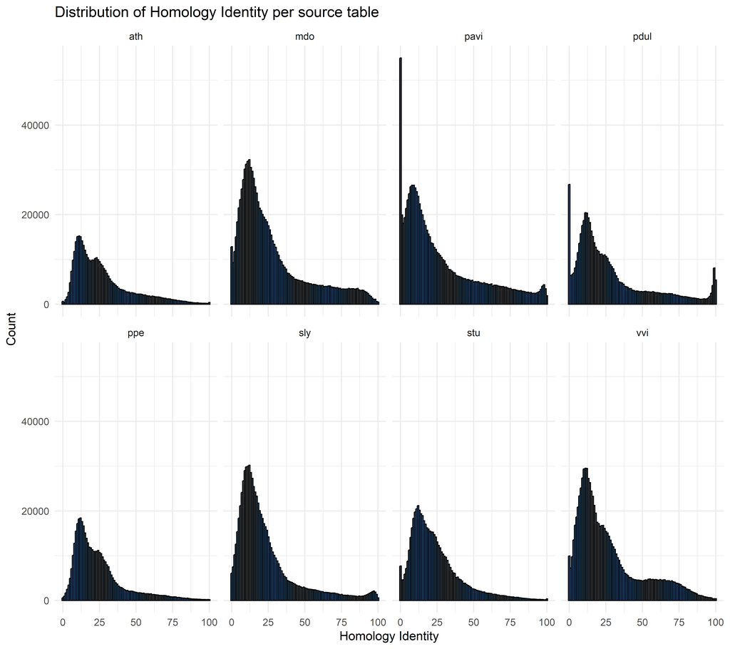

```r
ggplot(comparaPlants, aes(x = homology_identity)) +
  geom_histogram(binwidth = 1, fill = "steelblue", color = "black") +
  facet_wrap(~ source, ncol = 4) +
  theme_minimal() +
  labs(
    title = "Distribution of Homology Identity per source table",
    x = "Homology Identity",
    y = "Count"
  )
```

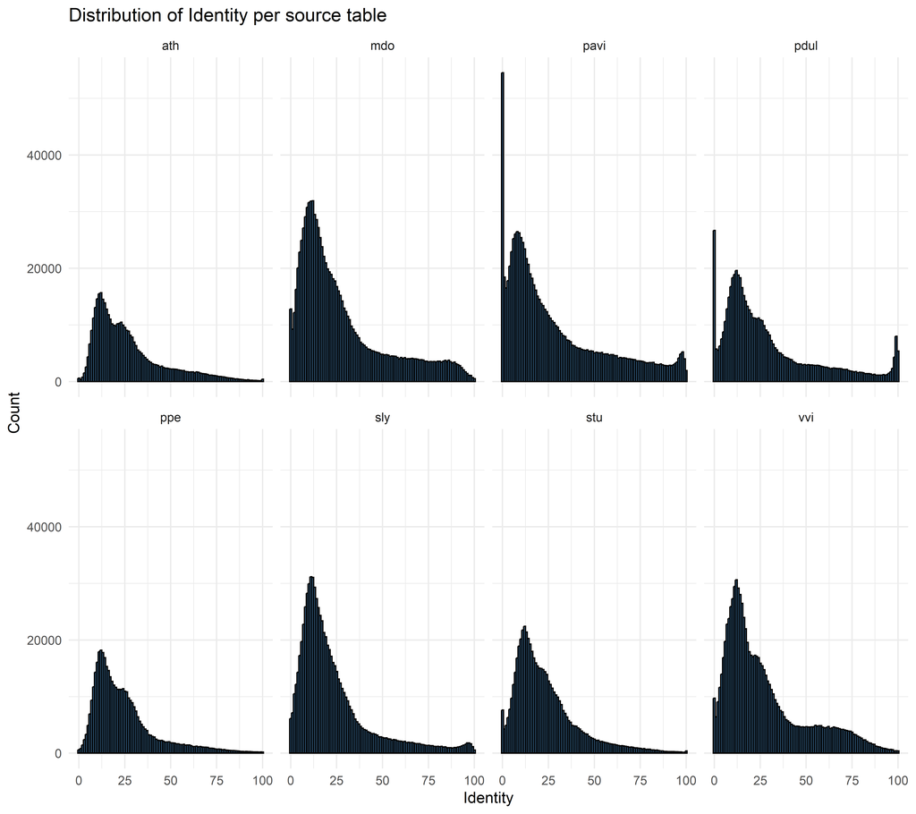

```r
ggplot(comparaPlants, aes(x = identity)) +
  geom_histogram(binwidth = 1, fill = "steelblue", color = "black") +
  facet_wrap(~ source, ncol = 4) +
  theme_minimal() +
  labs(
    title = "Distribution of Identity per source table",
    x = "Identity",
    y = "Count"
  )
```

```r
table(comparaPlants$species, comparaPlants$homology_species)
```

```
##
##                          arabidopsis_thaliana malus_domestica_golden
##   arabidopsis_thaliana                 347621                      0
##   malus_domestica_golden                38225                 793995
##   prunus_avium                          24682                  34506
##   prunus_dulcis                         25336                  11435
##   prunus_persica                            0                      0
##   solanum_lycopersicum                  27384                      0
##   solanum_tuberosum                         0                      0
##   vitis_vinifera                        25989                  39802
##
##                          prunus_avium prunus_dulcis prunus_persica
##   arabidopsis_thaliana              0             0          26435
##   malus_domestica_golden            0         23330          36512
##   prunus_avium                 717612         25566          23347
##   prunus_dulcis                     0        479660          22376
##   prunus_persica                    0             0         407396
##   solanum_lycopersicum              0             0          26729
##   solanum_tuberosum                 0             0            959
##   vitis_vinifera                    0         27367          29425
##
##                          solanum_lycopersicum solanum_tuberosum vitis_vinifera
##   arabidopsis_thaliana                      0             29286              0
##   malus_domestica_golden                39284             40163              0
##   prunus_avium                          26414             27137          28571
##   prunus_dulcis                         26027             27047              0
##   prunus_persica                            0             27951              0
##   solanum_lycopersicum                 682397             24895              0
##   solanum_tuberosum                         0            579108              0
##   vitis_vinifera                        26820             29861         684426
```

```r
ind = intersect(grep('prunus|arabidopsis', comparaPlants$species), grep('prunus|arabidopsis', comparaPlants$homology_species))
table(comparaPlants$species[ind], comparaPlants$homology_species[ind])
```

```
##
##                        arabidopsis_thaliana prunus_avium prunus_dulcis
##   arabidopsis_thaliana               347621            0             0
##   prunus_avium                        24682       717612         25566
##   prunus_dulcis                       25336            0        479660
##   prunus_persica                          0            0             0
##
##                        prunus_persica
##   arabidopsis_thaliana          26435
##   prunus_avium                  23347
##   prunus_dulcis                 22376
##   prunus_persica               407396
```

```r
ind = intersect(grep('solanum|arabidopsis', comparaPlants$species), grep('solanum|arabidopsis', comparaPlants$homology_species))
table(comparaPlants$species[ind], comparaPlants$homology_species[ind])
```

```
##
##                        arabidopsis_thaliana solanum_lycopersicum
##   arabidopsis_thaliana               347621                    0
##   solanum_lycopersicum                27384               682397
##   solanum_tuberosum                       0                    0
##
##                        solanum_tuberosum
##   arabidopsis_thaliana             29286
##   solanum_lycopersicum             24895
##   solanum_tuberosum               579108
```

# 6 high confidence

```r
ind = which(comparaPlants$is_high_confidence == 1)
comparaPlants.hc = comparaPlants[ind, ]
rm(comparaPlants)
gc()
```

```
##             used   (Mb) gc trigger   (Mb)  max used   (Mb)
## Ncells   7813353  417.3   18672927  997.3  13373125  714.3
## Vcells 131655566 1004.5  286438707 2185.4 286438707 2185.4
```

```r
table(comparaPlants.hc$species, comparaPlants.hc$homology_species)
```

```
##
##                          arabidopsis_thaliana malus_domestica_golden
##   arabidopsis_thaliana                      0                      0
##   malus_domestica_golden                22396                      0
##   prunus_avium                           4504                  18858
##   prunus_dulcis                         16421                   5924
##   prunus_persica                            0                      0
##   solanum_lycopersicum                  15531                      0
##   solanum_tuberosum                         0                      0
##   vitis_vinifera                        14504                  20663
##
##                          prunus_dulcis prunus_persica solanum_lycopersicum
##   arabidopsis_thaliana               0          16851                    0
##   malus_domestica_golden         17438          25521                20866
##   prunus_avium                   14516          16214                12097
##   prunus_dulcis                      0          19765                13297
##   prunus_persica                     0              0                    0
##   solanum_lycopersicum               0          14145                    0
##   solanum_tuberosum                  0            525                    0
##   vitis_vinifera                 13987          15458                15141
##
##                          solanum_tuberosum vitis_vinifera
##   arabidopsis_thaliana               15040              0
##   malus_domestica_golden             20832              0
##   prunus_avium                       12421          12939
##   prunus_dulcis                      13326              0
##   prunus_persica                     13844              0
##   solanum_lycopersicum               19706              0
##   solanum_tuberosum                      0              0
##   vitis_vinifera                     15292              0
```

```r
ind = intersect(grep('prunus|arabidopsis', comparaPlants.hc$species), grep('prunus|arabidopsis', comparaPlants.hc$homology_species))
table(comparaPlants.hc$species[ind], comparaPlants.hc$homology_species[ind])
```

```
##
##                        arabidopsis_thaliana prunus_dulcis prunus_persica
##   arabidopsis_thaliana                    0             0          16851
##   prunus_avium                         4504         14516          16214
##   prunus_dulcis                       16421             0          19765
```

```r
ind = intersect(grep('solanum|arabidopsis', comparaPlants.hc$species), grep('solanum|arabidopsis', comparaPlants.hc$homology_species))
table(comparaPlants.hc$species[ind], comparaPlants.hc$homology_species[ind])
```

```
##
##                        arabidopsis_thaliana solanum_tuberosum
##   arabidopsis_thaliana                    0             15040
##   solanum_lycopersicum                15531             19706
```

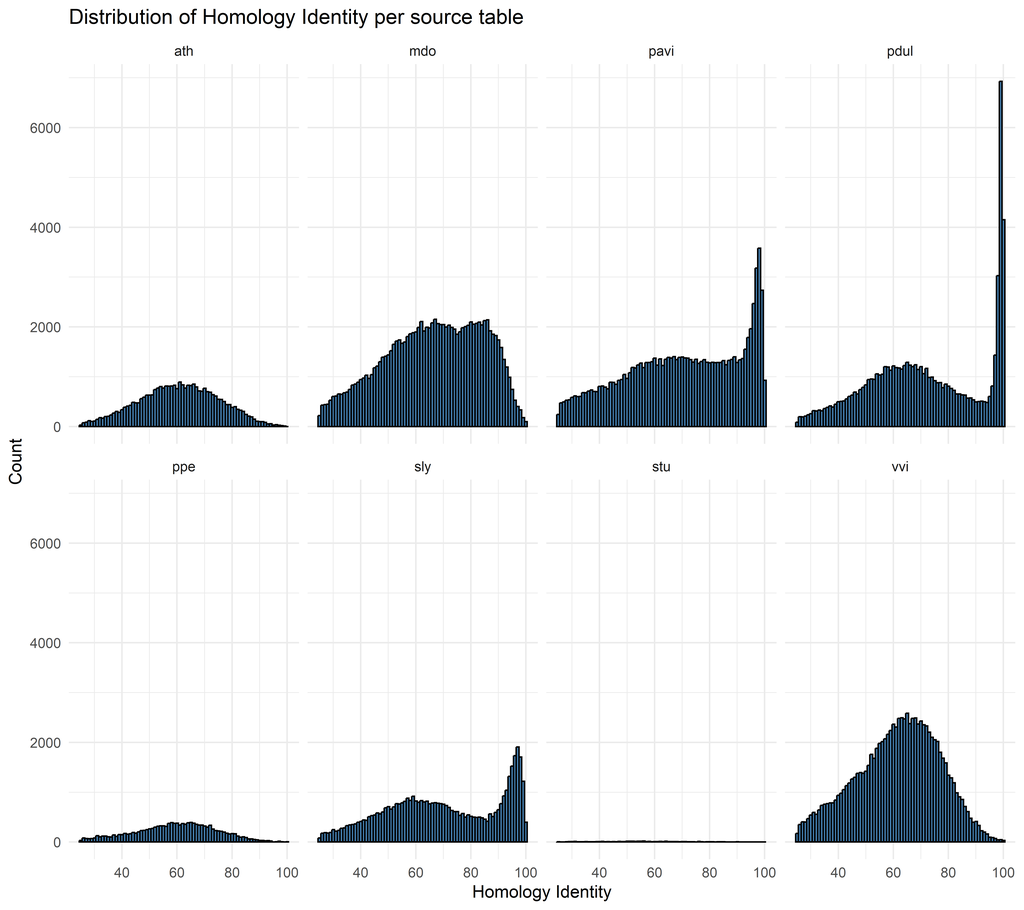

```r
ggplot(comparaPlants.hc, aes(x = homology_identity)) +
  geom_histogram(binwidth = 1, fill = "steelblue", color = "black") +
  facet_wrap(~ source, ncol = 4) +
  theme_minimal() +
  labs(
    title = "Distribution of Homology Identity per source table",
    x = "Homology Identity",
    y = "Count"
  )
```

```r
# file_path = '../intermediate/comparaPlants.high_confidence.txt'
# data.table::fwrite(comparaPlants.hc, file_path, sep = '\t')
# root_dir = dirname(file_path)
# file_name = basename(file_path)
# zip::zip(zipfile = paste0(file_path, ".zip"),
#     files = file_name,
#     root = root_dir)
# file.remove(file_path)
```

# 7 with ath pairs

```r
comparaPlants.filtered = comparaPlants.hc[
  grepl("arabidopsis", comparaPlants.hc$species, ignore.case = TRUE) |
    grepl("arabidopsis", comparaPlants.hc$homology_species, ignore.case = TRUE), ]
rm(comparaPlants.hc)
gc()
```

```
##            used  (Mb) gc trigger   (Mb)  max used   (Mb)
## Ncells  2698392 144.2   14938342  797.8  14361254  767.0
## Vcells 37052607 282.7  229150966 1748.3 286438707 2185.4
```

```r
table(comparaPlants.filtered$species, comparaPlants.filtered$homology_species)
```

```
##
##                          arabidopsis_thaliana prunus_persica solanum_tuberosum
##   arabidopsis_thaliana                      0          16851             15040
##   malus_domestica_golden                22396              0                 0
##   prunus_avium                           4504              0                 0
##   prunus_dulcis                         16421              0                 0
##   solanum_lycopersicum                  15531              0                 0
##   vitis_vinifera                        14504              0                 0
```

```r
# file_path = '../intermediate/comparaPlants_high_confidence_ath_pairs.txt'
# data.table::fwrite(comparaPlants.filtered, file_path, sep = '\t')
# root_dir = dirname(file_path)
# file_name = basename(file_path)
# zip::zip(zipfile = paste0(file_path, ".zip"),
#     files = file_name,
#     root = root_dir)
# file.remove(file_path)
```

# 8 ath-plant pairs

```r
cols_to_keep = c("gene_stable_id", "protein_stable_id", "species",
                 "homology_gene_stable_id", "homology_protein_stable_id", "homology_species",
                 "homology_identity")

comparaPlants.filtered = comparaPlants.filtered[, cols_to_keep, drop = FALSE]

ind1 = grep("arabidopsis", comparaPlants.filtered$homology_species, ignore.case = TRUE)
ind2 = grep("arabidopsis", comparaPlants.filtered$species, ignore.case = TRUE)


df_sub2 = comparaPlants.filtered[ind2, ]
cols_first = c(
  "gene_stable_id", "protein_stable_id", "species",
  "homology_gene_stable_id", "homology_protein_stable_id", "homology_species",
  "homology_identity"
)
df_sub2 = df_sub2[, cols_first]


df_sub1 = comparaPlants.filtered[ind1, ]
cols_first = c(
  "homology_gene_stable_id", "homology_protein_stable_id", "homology_species",
  "gene_stable_id", "protein_stable_id", "species",
  "homology_identity"
)
df_sub1 = df_sub1[, cols_first]

colnames(df_sub1) = colnames(df_sub2)
rm(comparaPlants.filtered)
gc()
```

```
##            used  (Mb) gc trigger   (Mb)  max used   (Mb)
## Ncells  2698843 144.2   11950674  638.3  14361254  767.0
## Vcells 36316618 277.1  183320773 1398.7 286438707 2185.4
```

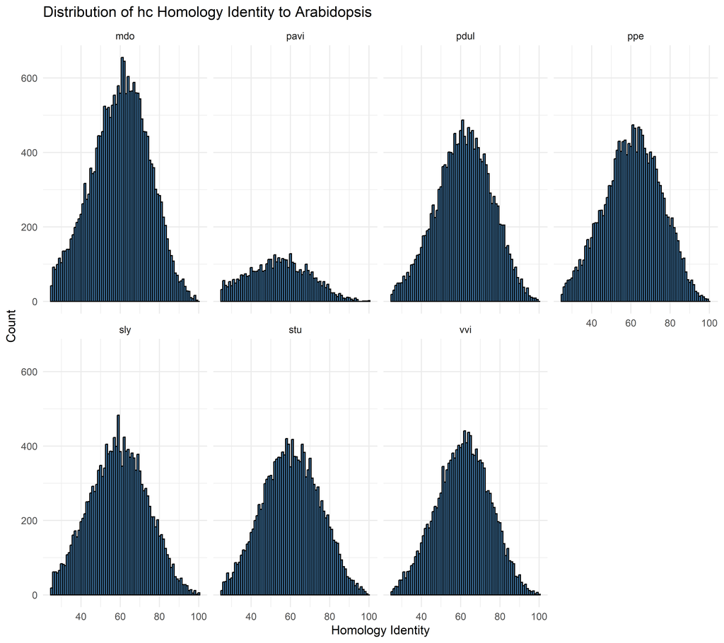

```r
df = rbind(df_sub2, df_sub1)
setDT(df)
df[, protein_stable_id := NULL]
# rm(df_sub1)
# rm(df_sub2)
df[, species := pattern_mapP[species]]
df[, homology_species := pattern_mapP[homology_species]]

ggplot(df, aes(x = homology_identity)) +
  geom_histogram(binwidth = 1, fill = "steelblue", color = "black") +
  facet_wrap(~ homology_species, ncol = 4) +
  theme_minimal() +
  labs(
    title = "Distribution of hc Homology Identity to Arabidopsis",
    x = "Homology Identity",
    y = "Count"
  )
```

```r
df[, homology_identity := NULL]
df[homology_species %in% c("ppe", "pdul"), homology_gene_stable_id := homology_protein_stable_id]
df[, homology_protein_stable_id := NULL]

colnames(df) = c("from",
                 "from_plant",
                 "to",
                 "to_plant")
df$source = 'compara'
```

# 9 translate to ref geneID

```r
df = reference[df, on = .(Ortholog = to, to_plant),
                .(from, from_plant, to = sourceID, to_plant, source)]
df = unique(df)
df[is.na(to), .N, by = to_plant]
```

```
##    to_plant     N
##      <char> <int>
## 1:      ppe   652
## 2:      stu    28
## 3:      mdo  1132
## 4:     pavi   351
## 5:     pdul   803
## 6:      sly   859
## 7:      vvi   909
```

```r
df = df[!is.na(df$to), ]
table(df$from_plant, df$to_plant)
```

```
##
##         mdo  pavi  pdul   ppe   sly   stu   vvi
##   ath 20997  4367 15975 16193 14733 15035 13825
```

```r
df %>%
  dplyr::group_by(to_plant) %>%
  dplyr::slice_head(n = 2) %>%
  dplyr::bind_rows(df %>% dplyr::group_by(to_plant) %>% dplyr::slice_tail(n = 2)) %>%
  dplyr::arrange(to_plant) %>%
  dplyr::ungroup() -> first_last_two_per_plant
print(first_last_two_per_plant, n = nrow(first_last_two_per_plant))
```

```
## # A tibble: 28 × 5
##    from      from_plant to                         to_plant source
##    <chr>     <chr>      <chr>                      <chr>    <chr>
##  1 AT4G39400 ath        Maldo.hc.v1a1.ch2A.g27501  mdo      compara
##  2 AT4G39400 ath        Maldo.hc.v1a1.ch15A.g17036 mdo      compara
##  3 AT1G65880 ath        Maldo.hc.v1a1.ch17A.g24066 mdo      compara
##  4 AT5G52820 ath        Maldo.hc.v1a1.ch17A.g24067 mdo      compara
##  5 AT2G22690 ath        FUN_021390                 pavi     compara
##  6 AT4G37880 ath        FUN_021390                 pavi     compara
##  7 AT4G39770 ath        FUN_021012                 pavi     compara
##  8 AT4G21740 ath        FUN_032538                 pavi     compara
##  9 AT4G37540 ath        TexasF1_G22582             pdul     compara
## 10 AT5G67420 ath        TexasF1_G22582             pdul     compara
## 11 AT4G15960 ath        TexasF1_G27715             pdul     compara
## 12 AT3G45140 ath        TexasF1_G6796              pdul     compara
```

[output cut: 16 more lines]

# 10 write and zip

```r
file_path = '../intermediate/comparaPlants-hc_cleaned.txt'
data.table::fwrite(df, file_path, sep = '\t')
root_dir = dirname(file_path)
file_name = basename(file_path)
zip::zip(zipfile = paste0(file_path, ".zip"),
    files = file_name,
    root = root_dir)
file.remove(file_path)
```

```
## [1] TRUE
```